# Aprendizaje automático (Machine Learning)

2022-05-05

## Antes de empezar…

Instala las librerías necesarias (copia y pega en la terminal; no descomentes la línea)…

```r
# install.packages(c("tidymodels", "vip", "mlbench", "rpart.plot"))
```

## Aprendizaje automático (Machine Learning)

El aprendizaje automático (Machine Learning) es una rama de la inteligencia artificial basada en la creación de modelos computacionales capaces de aprender de los datos, identificar patrones y tomar decisiones con una mínima intervención humana. Los modelos de aprendizaje automáticos pueden llegar a ser muy complejos, lo que hace que no siempre sean fácilmente interpretables (aunque existen excepciones, tal y como veremos).

Aunque los modelos de aprendizaje automático pueden resolver muchos tipos de tareas, nos centraremos en:

- Regresión: Predicción de una magnitud continua. Por ejemplo: ¿qué temperatura hará mañana?
- Clasificación: Predicción de categorías (clases). Por ejemplo, ¿qué enfermedad sufre el paciente: gripe, covid, o ninguna?

## Ejemplo: los peligros del aprendizaje automático

Los modelos lineales construidos con `lm` pueden considerarse modelos (sencillos) de aprendizaje automático. Para darles potencia, podemos emplear **predictores (features)** más complejos (al trabajo de crear predictores a veces se le conoce como **feature engineering**), como expresiones polinomiales.

Usa `lm` para ajustar los datos de “lm_ml.csv”. Estos datos sintéticios han sido generados usando
$$y = cos(4 * x + 4) + \epsilon.$$

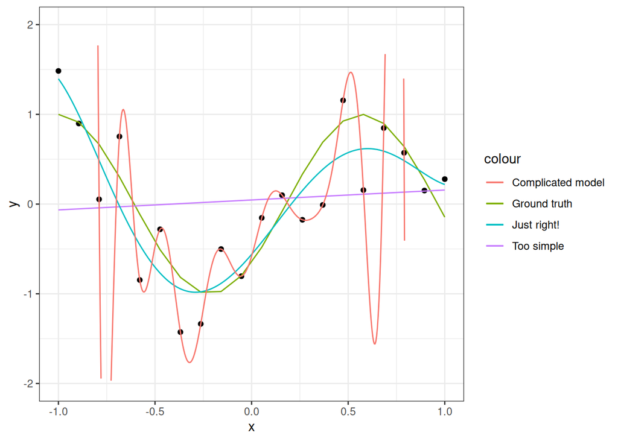

```r
plot_model = function(model, col) {
  xxx = seq(-1, 1, len=500)
  new_data = data.frame('x' = xxx)
  new_data$preds = predict(model, new_data)
  return(
    geom_line(data = new_data, aes(x = xxx, y = preds, col = col))
  )
}


df = read.csv("data/lm_ml.csv")

lmf1 = lm(y ~ x, data = df)
lmf2 = lm(y ~ poly(x, 5), data = df)
lmf3 = lm(y ~ poly(x, 19), data = df)


p <- ggplot(df, aes(x = x, y = y)) + geom_point()
p +
  geom_line(aes(x = x, y = cos(4 * x + 4), col = "Ground truth")) +
  plot_model(lmf1, col = "Too simple") +
  plot_model(lmf2, col="Just right!") +
  plot_model(lmf3, col="Complicated model") +
  ylim(-2, 2)
```

```r
evaluate_model = function(model) {
  yardstick::rmse_vec(truth = df$y, estimate = predict(model))
}

print(paste("Model 1 has error: ", evaluate_model(lmf1)))
```

```
## [1] "Model 1 has error:  0.759274852104855"
```

```r
print(paste("Model 2 has error: ", evaluate_model(lmf2)))
```

```
## [1] "Model 2 has error:  0.374104368880922"
```

```r
print(paste("Model 3 has error: ", evaluate_model(lmf3)))
```

```
## [1] "Model 3 has error:  2.49824573898517e-16"
```

```r
evaluate_model = function(model) {
  eval_points = seq(-1, 1, len=100)
  yardstick::rmse_vec(
    truth = cos(4 * eval_points + 4),
    estimate = predict(model, data.frame(x=eval_points))
  )
}

print(paste("Model 1 has error: ", evaluate_model(lmf1)))
```

```
## [1] "Model 1 has error:  0.684026690892578"
```

```r
print(paste("Model 2 has error: ", evaluate_model(lmf2)))
```

```
## [1] "Model 2 has error:  0.233099770786972"
```

```r
print(paste("Model 3 has error: ", evaluate_model(lmf3)))
```

```
## [1] "Model 3 has error:  102.368547848092"
```

**Moraleja**: El rendimiento de un modelo requiere de una **métrica** y debe **evaluarse fuera del conjunto de entrenamiento**. Esto nos llevará a hablar de conjuntos de **entrenamiento** y **test**.

En las siguientes secciones, haremos uso de la librería `tidymodels` para crear y evaluar modelos de aprendizaje automático. Existen otras librerías fantásticas como `caret` y `mlr3` (o su antecesora `mlr`) que puedes probar.

```r
library('tidymodels')
```

## Árboles de decisión.

Los Árboles de decisión son una buena elección si deseas construir un modelo de aprendizaje automático interpretable.

### Ejemplo: clasificación de animales

El dataset `Zoo` contiene 101 casos y 17 variables de observaciones realizadas en varios animales; 16 de estas variables son lógicas, indicando la presencia o ausencia de alguna característica, y la variable `type` es un factor que contiene las clases de animales que deseamos predecir.

```r
data(Zoo, package = "mlbench")
zoo = Zoo %>% as_tibble %>% mutate_if(is.logical, as.factor)
```

```r
# 1) Creación de un árbol de decisión
tree_spec =
  decision_tree(tree_depth = 3) %>%
  set_engine("rpart") %>%
  set_mode("classification")

# 2) El árbol aprende a partir de los datos
fitted_tree = fit(tree_spec, type ~ ., data = zoo)
```

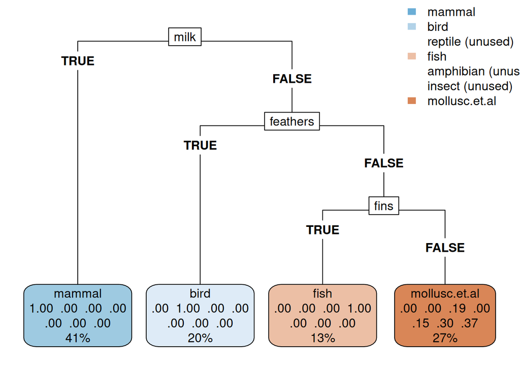

```r
# 3) Podemos visualizar la toma de decisiones del árbol.
library("rpart.plot")
# xtract_fit_engine()
rpart.plot(fitted_tree$fit, roundint = FALSE,
           box.palette = "BuBn",
           type = 5)
```

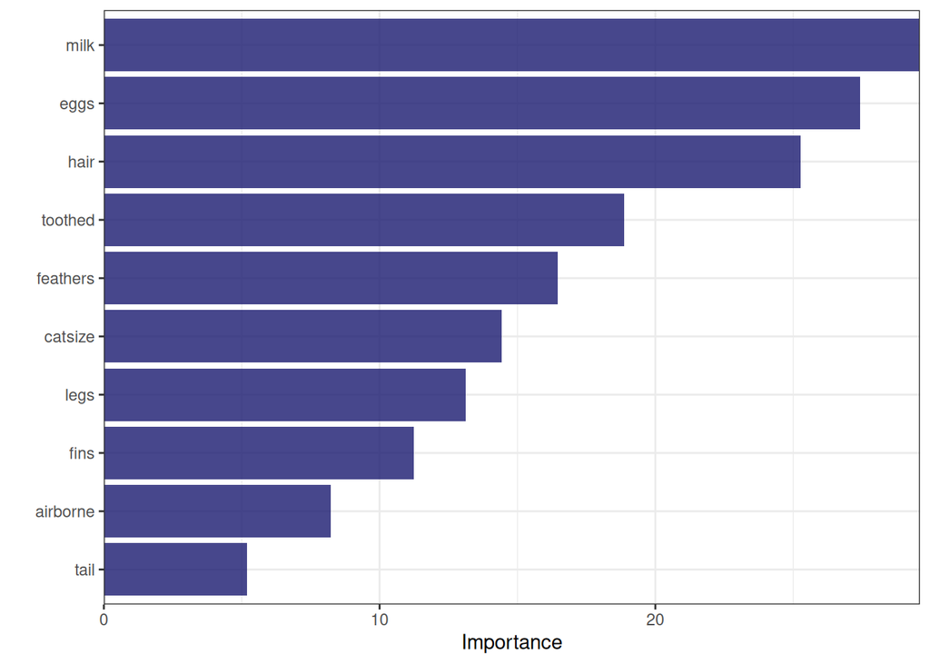

```r
# 4) También es posible visualizar qué características son las más relevantes
# a la hora de predecir la clase... ¡Esto nos permite aprender del modelo!
library("vip")
fitted_tree %>%
  vip(geom = "col", aesthetics = list(fill = "midnightblue", alpha = 0.8)) +
  scale_y_continuous(expand = c(0, 0))
```

Aunque las decisiones del árbol parecen razonables es buena práctica evaluar el rendimiento del modelo. Para ello seguiremos las lecciones aprendidas con el ejemplo de regresión debemos:

- Elegir una métrica: emplearemos `accuracy`, la proporción de predicciones correctas.
- Dividir el conjunto de datos en entrenamiento y test.

```r
set.seed(123)
zoo_split = initial_split(zoo, strata = type, prop = 3 / 4)
zoo_train = training(zoo_split)
zoo_test = testing(zoo_split)
```

## Ejercicio: Rendimiento del sistema

Usa los conjuntos de entrenamiento y test para obtener el rendimiento del árbol de decisión. Sigue los pasos indicados en los comentarios:

```r
# 1) Repite el entrenamiento, pero esta vez usa el conjunto de entrenamiento

# 2) Usa predict() para obtener predicciones sobre el conjunto de test. Guarda
# las predicciones en la variable preds

# 3) Calcula el porcentaje de predicciones correctas comparando la clase real
# (zoo_test$type) con preds. Puedes usar las funciones accuracy (o accuracy_vec)
```

# Ejemplo: Rendimiento del sistema mediante Monte Carlo

Podemos obtener una mejor estimación del `accuracy` del sistema repitiendo varias veces el procedimiento anterior y luego promediando los resultados (¡y además podemos obtener una estimación del error!). Aunque existen varios procedimientos para realizar esta repetición, el más sencillo de entender quizás sea Monte Carlo Cross-validation (validación cruzada de Monte Carlo):

```r
folds = mc_cv(zoo, times = 10, prop = 9 / 10)
performance = tree_spec %>% fit_resamples(type ~ ., resamples = folds,
                                          metrics=metric_set(accuracy))

collect_metrics(performance)
```

```
## # A tibble: 1 × 6
##   .metric  .estimator  mean     n std_err .config
##   <chr>    <chr>      <dbl> <int>   <dbl> <chr>
## 1 accuracy multiclass 0.809    10  0.0370 Preprocessor1_Model1
```

# Ejemplo: Elección de hiperparámetros

En la construcción del modelo especificamos a mano el **hiperparámetro** `tree_depth = 3`. Aunque se puede intentar elegir a mano (¡ojo porque esto puede llevar a overfitting!), lo mejor es automatizar el proceso

```r
tree_spec = decision_tree(
  tree_depth = tune(),
  cost_complexity = tune()
) %>%
  set_engine("rpart") %>%
  set_mode("classification")

tree_grid = grid_regular(cost_complexity(),
                         tree_depth(),
                         levels = 3)
tree_grid
```

```
## # A tibble: 9 × 2
##   cost_complexity tree_depth
##             <dbl>      <int>
## 1    0.0000000001          1
## 2    0.00000316            1
## 3    0.1                   1
## 4    0.0000000001          8
## 5    0.00000316            8
## 6    0.1                   8
## 7    0.0000000001         15
## 8    0.00000316           15
## 9    0.1                  15
```

```r
tree_res =  tree_spec %>%
  tune_grid(
    type ~ .,
    resamples = folds,
    grid = tree_grid
  )
```

[output not shown]

[output not shown]

```r
collect_metrics(tree_res)
```

```
## # A tibble: 18 × 8
##    cost_complexity tree_depth .metric  .estimator  mean     n std_err .config
##              <dbl>      <int> <chr>    <chr>      <dbl> <int>   <dbl> <chr>
##  1    0.0000000001          1 accuracy multiclass 0.655    10 0.0326  Preproces…
##  2    0.0000000001          1 roc_auc  hand_till  0.725    10 0.0150  Preproces…
##  3    0.00000316            1 accuracy multiclass 0.655    10 0.0326  Preproces…
##  4    0.00000316            1 roc_auc  hand_till  0.725    10 0.0150  Preproces…
##  5    0.1                   1 accuracy multiclass 0.655    10 0.0326  Preproces…
##  6    0.1                   1 roc_auc  hand_till  0.725    10 0.0150  Preproces…
##  7    0.0000000001          8 accuracy multiclass 0.827    10 0.0316  Preproces…
##  8    0.0000000001          8 roc_auc  hand_till  0.964    10 0.0125  Preproces…
##  9    0.00000316            8 accuracy multiclass 0.827    10 0.0316  Preproces…
## 10    0.00000316            8 roc_auc  hand_till  0.964    10 0.0125  Preproces…
## 11    0.1                   8 accuracy multiclass 0.818    10 0.0303  Preproces…
## 12    0.1                   8 roc_auc  hand_till  0.95     10 0.00962 Preproces…
## 13    0.0000000001         15 accuracy multiclass 0.827    10 0.0316  Preproces…
## 14    0.0000000001         15 roc_auc  hand_till  0.964    10 0.0125  Preproces…
## 15    0.00000316           15 accuracy multiclass 0.827    10 0.0316  Preproces…
## 16    0.00000316           15 roc_auc  hand_till  0.964    10 0.0125  Preproces…
## 17    0.1                  15 accuracy multiclass 0.818    10 0.0303  Preproces…
## 18    0.1                  15 roc_auc  hand_till  0.95     10 0.00962 Preproces…
```

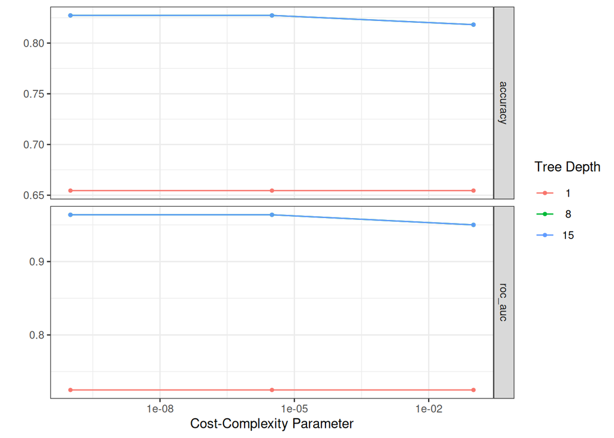

```r
autoplot(tree_res)
```

```r
show_best(tree_res, "accuracy")
```

```
## # A tibble: 5 × 8
##   cost_complexity tree_depth .metric  .estimator  mean     n std_err .config
##             <dbl>      <int> <chr>    <chr>      <dbl> <int>   <dbl> <chr>
## 1    0.0000000001          8 accuracy multiclass 0.827    10  0.0316 Preprocess…
## 2    0.00000316            8 accuracy multiclass 0.827    10  0.0316 Preprocess…
## 3    0.0000000001         15 accuracy multiclass 0.827    10  0.0316 Preprocess…
## 4    0.00000316           15 accuracy multiclass 0.827    10  0.0316 Preprocess…
## 5    0.1                   8 accuracy multiclass 0.818    10  0.0303 Preprocess…
```

```r
select_best(tree_res, "accuracy")
```

```
## # A tibble: 1 × 3
##   cost_complexity tree_depth .config
##             <dbl>      <int> <chr>
## 1    0.0000000001          8 Preprocessor1_Model4
```

```r
final_tree = finalize_model(tree_spec, select_best(tree_res, "accuracy"))
final_fit = fit(final_tree, type ~ ., zoo)
```

### Ejercicio: regresión con el dataset Boston

El conjunto de datos `Boston` contiene varias estadísticas para 506 vecindarios de Boston. Construye un modelo de regresión que prediga el valor medio de las viviendas ocupadas por sus propietarios (`medv`). (Nota: el conjunto de datos `Boston` es bastante antiguo y contiene algunas variables realmente desafortunadas.)

```r
data("Boston", package = "MASS")
Boston = as_tibble(Boston)

# En este ejercicio, tunearemos las variables y luego evaluaremos el rendimiento.
# Creeamos conjuntos de entrenamiento y test
```

## Preprocesado y otros clasificadores

A lo largo de los siguientes ejemplos/ejercicios emplearemos el dataset de “diabetes.csv” para crear un clasificador capaz de predecir si una persona tiene diabetes o no.

```r
diabetes = read.csv(file = "data/diabetes.csv") %>% as_tibble
```

### Ejemplo: exploración de datos y visualización de predictores (features)

Aunque no lo hemos hecho en el ejemplo de clasificación de animales, siempre debemos empezar el problema con una exploración de los datos.

```r
diabetes %>% glimpse()
```

```
## Rows: 15,000
## Columns: 10
## $ PatientID              <int> 1354778, 1147438, 1640031, 1883350, 1424119, 16…
## $ Pregnancies            <int> 0, 8, 7, 9, 1, 0, 0, 0, 8, 1, 1, 3, 5, 7, 0, 3,…
## $ PlasmaGlucose          <int> 171, 92, 115, 103, 85, 82, 133, 67, 80, 72, 88,…
## $ DiastolicBloodPressure <int> 80, 93, 47, 78, 59, 92, 47, 87, 95, 31, 86, 96,…
## $ TricepsThickness       <int> 34, 47, 52, 25, 27, 9, 19, 43, 33, 40, 11, 31, …
## $ SerumInsulin           <int> 23, 36, 35, 304, 35, 253, 227, 36, 24, 42, 58, …
## $ BMI                    <dbl> 43.50973, 21.24058, 41.51152, 29.58219, 42.6045…
## $ DiabetesPedigree       <dbl> 1.21319135, 0.15836498, 0.07901857, 1.28286985,…
## $ Age                    <int> 21, 23, 23, 43, 22, 26, 21, 26, 53, 26, 22, 23,…
## $ Diabetic               <int> 0, 0, 0, 1, 0, 0, 0, 0, 1, 0, 0, 0, 1, 0, 0, 1,…
```

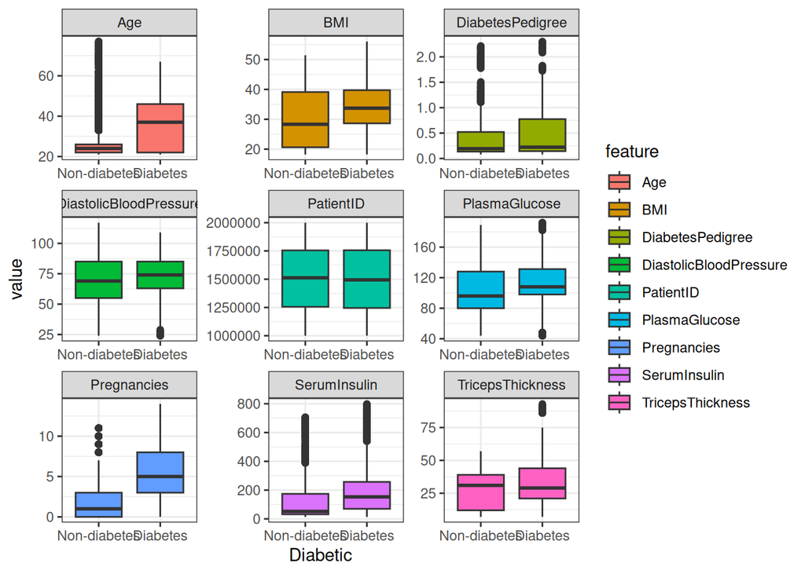

```r
diabetes =
  diabetes %>%
  mutate(Diabetic = as.factor(Diabetic)) %>%
  mutate(Diabetic = fct_recode(Diabetic, "Diabetes"="1", "Non-diabetes"="0"))


ggdiabetes = diabetes %>% pivot_longer(PatientID:Age, names_to="feature", values_to="value")

ggplot(ggdiabetes, aes(x = Diabetic, y=value, fill=feature)) + geom_boxplot() +
  facet_wrap(~feature, scale="free")
```

Fíjate que cada predictor tiene una escala distinta. Esta diferencia de escalas puede perjudicar a algunos clasificadores/regresores por lo que es buena idea hacer un **preprocesado de datos** para **normalizarlos**. Para ilustrar como normalizar datos usaremos como clasificador una **red neuronal**. Además de ser uno de los algoritmos más potentes, las redes neuronales necesitan que los datos estén en la misma escala para funcionar adecuadamente.

## Ejemplo: normalización de datos

```r
# El preprocesado de datos involucra aprender cómo transformar los datos,
# por lo que debe aplicarse a los datos de entrenamiento
diabetes_split = initial_split(diabetes, split = 3/4, strata = Diabetic)
diabetes_train = training(diabetes_split)
diabetes_test = testing(diabetes_split)

# Para preprocesar los datos, creamos una receta de preprocesado
diabetes_rec = recipe(Diabetic ~ ., data = diabetes_train)
diabetes_rec =
  diabetes_rec %>%
  update_role(PatientID,new_role = "ID" ) %>%
  step_log(PlasmaGlucose) %>%
  step_normalize(all_numeric_predictors())

print(diabetes_rec)
```

```
## ── Recipe ──────────────────────────────────────────────────────────────────────
```

```
## ── Inputs
```

```
## Number of variables by role
```

```
## outcome:   1
## predictor: 8
## ID:        1
```

```
## ── Operations
```

```
## • Log transformation on: PlasmaGlucose
```

```
## • Centering and scaling for: all_numeric_predictors()
```

Aunque es posible preprocesar los datos y luego crear un modelo sobre los datos transformados, lo cierto es que podemos integrar ambos pasos (preprocesado y modelado) en un único **workflow**.

### Ejemplo: workflows

```r
diabetes_model = mlp(hidden_units = 50, epochs=100) %>% set_mode("classification")

diabetes_wflow =
  workflow() %>%
  add_recipe(diabetes_rec) %>%
  add_model(diabetes_model)

diabetes_fit = fit(diabetes_wflow, data = diabetes_train)
preds = predict(diabetes_fit, diabetes_test)

print(paste("Accuracy =", accuracy_vec(truth = diabetes_test$Diabetic, preds$.pred_class)))
```

```
## [1] "Accuracy = 0.935733333333333"
```

### Ejercicio

Mejora la red neuronal tuneando sus parámetros.